# Introduction to R - Solutions

Simon Munzert

18.09.2017

#### In-class exercise

##### 1. How many flights started from all the NYC airports in 2013?

```r
nrow(flights)
```

```
## [1] 336776
```

##### 2. How many flights started from NYC airports in 2013, by month?

```r
table(flights$month)
```

```
##
##     1     2     3     4     5     6     7     8     9    10    11    12
## 27004 24951 28834 28330 28796 28243 29425 29327 27574 28889 27268 28135
```

```r
flights_by_month <- group_by(flights, month)
summarize(flights_by_month, count = n())
```

```
## # A tibble: 12 x 2
##    month count
##    <int> <int>
##  1     1 27004
##  2     2 24951
##  3     3 28834
##  4     4 28330
##  5     5 28796
##  6     6 28243
##  7     7 29425
##  8     8 29327
##  9     9 27574
## 10    10 28889
## 11    11 27268
## 12    12 28135
```

##### 3. Which were the most frequent destinations?

```r
flights_by_dest <- group_by(flights, dest)
dat <- summarize(flights_by_dest, n_per_dest = n())
arrange(dat, desc(n_per_dest))
```

```
## # A tibble: 105 x 2
##     dest n_per_dest
##    <chr>      <int>
##  1   ORD      17283
##  2   ATL      17215
##  3   LAX      16174
##  4   BOS      15508
##  5   MCO      14082
##  6   CLT      14064
##  7   SFO      13331
##  8   FLL      12055
##  9   MIA      11728
## 10   DCA       9705
## # ... with 95 more rows
```

```r
# alternative:
# sort(table(flights$dest))
```

##### 4. Which flights went from JFK to PWM (Portland) in January between midnight and 5am?

```r
dat <- filter(flights, origin == "JFK", month == 1, dest == "PWM", dep_time < 500)
dat
```

```
## # A tibble: 2 x 19
##    year month   day dep_time sched_dep_time dep_delay arr_time
##   <int> <int> <int>    <int>          <int>     <dbl>    <int>
## 1  2013     1     4      106           2245       141      201
## 2  2013     1    31       54           2250       124      152
## # ... with 12 more variables: sched_arr_time <int>, arr_delay <dbl>,
## #   carrier <chr>, flight <int>, tailnum <chr>, origin <chr>, dest <chr>,
## #   air_time <dbl>, distance <dbl>, hour <dbl>, minute <dbl>,
## #   time_hour <dttm>
```

##### 5. Which carrier had the biggest mean net delay (departure delay minus arrival delay), which the lowest?

```r
dat <- group_by(flights, carrier)
dat <- mutate(dat, net_delay = dep_delay - arr_delay)
dat_sum <- summarize(dat, delay_mean = mean(net_delay, na.rm= TRUE))
arrange(dat_sum, delay_mean)
```

```
## # A tibble: 16 x 2
##    carrier delay_mean
##      <chr>      <dbl>
##  1      F9 -1.7195301
##  2      FL -1.5099213
##  3      MQ -0.3293526
##  4      OO  0.6551724
##  5      US  1.6150976
##  6      YV  3.3419118
##  7      B6  3.5095746
##  8      EV  4.0424982
##  9      DL  7.5796089
## 10      WN  8.0125374
## 11      AA  8.2048393
## 12      UA  8.4588972
## 13      9E  9.0599052
## 14      VX 10.9921814
## 15      HA 11.8157895
## 16      AS 15.7616361
```

##### 6. Inspect visually how the net delays are distributed!

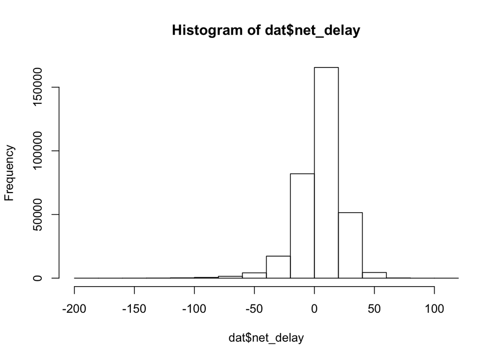

```r
hist(dat$net_delay)
```

##### 7. How are distance and net delay related?

```r
summary(lm(net_delay ~ distance, data = dat))
```

```
##
## Call:
## lm(formula = net_delay ~ distance, data = dat)
##
## Residuals:
##      Min       1Q   Median       3Q      Max
## -205.329   -8.615    2.082   11.120  103.928
##
## Coefficients:
##              Estimate Std. Error t value Pr(>|t|)
## (Intercept) 2.963e+00  5.459e-02   54.29   <2e-16 ***
## distance    2.572e-03  4.262e-05   60.35   <2e-16 ***
## ---
## Signif. codes:  0 '***' 0.001 '**' 0.01 '*' 0.05 '.' 0.1 ' ' 1
##
## Residual standard error: 17.94 on 327344 degrees of freedom
##   (9430 observations deleted due to missingness)
## Multiple R-squared:  0.011,  Adjusted R-squared:  0.011
## F-statistic:  3642 on 1 and 327344 DF,  p-value: < 2.2e-16
```

```r
with(dat, cor(net_delay, distance))
```

```
## [1] NA
```

#### Working with vectors

##### 1. Create a vector x with elements [0,4,8,12,16,20].

```r
x <- seq(0, 20, 4)
x
```

```
## [1]  0  4  8 12 16 20
```

##### 2. Create a vector y with elements [3,3,3,4,4,4,4,5,5,5,5,5].

```r
y <- c(3,3,3,4,4,4,4,5,5,5,5,5)
rep(c(3, 4, 5), c(3, 4, 5))
```

```
##  [1] 3 3 3 4 4 4 4 5 5 5 5 5
```

##### 3. Combine the first five elements of x with elements 2 to 12 of vector y to create a new vector z.

```r
z <- c(x[1:5], y[2:12])
```

##### 4. What’s the sum of all numbers between 1 and 100? Use the functions you learned in the vectors script to compute it!

```r
sum(seq(1, 100))
```

```
## [1] 5050
```

```r
sum(1:100)
```

```
## [1] 5050
```

##### 5. What’s the sum of all odd numbers between 1 and 100 squared?

```r
sum(seq(1, 100, 2)^2)
```

```
## [1] 166650
```

#### Working with data frames

##### 1. Inspect the “babynames” package! What data does it contain? Focus on the babynames data frame in the following.

```r
names(babynames)
```

```
## [1] "year" "sex"  "name" "n"    "prop"
```

```r
nrow(babynames)
```

```
## [1] 1858689
```

##### 2. Which time period does the data frame cover?

```r
unique(babynames$year)
```

```
##   [1] 1880 1881 1882 1883 1884 1885 1886 1887 1888 1889 1890 1891 1892 1893
##  [15] 1894 1895 1896 1897 1898 1899 1900 1901 1902 1903 1904 1905 1906 1907
##  [29] 1908 1909 1910 1911 1912 1913 1914 1915 1916 1917 1918 1919 1920 1921
##  [43] 1922 1923 1924 1925 1926 1927 1928 1929 1930 1931 1932 1933 1934 1935
##  [57] 1936 1937 1938 1939 1940 1941 1942 1943 1944 1945 1946 1947 1948 1949
##  [71] 1950 1951 1952 1953 1954 1955 1956 1957 1958 1959 1960 1961 1962 1963
##  [85] 1964 1965 1966 1967 1968 1969 1970 1971 1972 1973 1974 1975 1976 1977
##  [99] 1978 1979 1980 1981 1982 1983 1984 1985 1986 1987 1988 1989 1990 1991
## [113] 1992 1993 1994 1995 1996 1997 1998 1999 2000 2001 2002 2003 2004 2005
## [127] 2006 2007 2008 2009 2010 2011 2012 2013 2014 2015
```

```r
range(babynames$year)
```

```
## [1] 1880 2015
```

##### 3. What has been the most frequent name in the US since 1880? (hint: you might need the group_by() as well as the sum() function)

```r
babynames_byname <- group_by(babynames, name)
babynames_byname_sum <- summarize(babynames_byname, total = sum(n))
head(arrange(babynames_byname_sum, desc(total)))
```

```
## # A tibble: 6 x 2
##      name   total
##     <chr>   <int>
## 1   James 5144205
## 2    John 5117331
## 3  Robert 4823167
## 4 Michael 4345569
## 5    Mary 4133216
## 6 William 4087556
```

##### 4. Use graphical means to determine since which year the name “Kim” became more popular as a female than a male name! (hint: grouping by two variables is helpful here! For the plot, use “year” on the x axis and “total count” on the y axis! Furthermore, this Stackoverflow post helps you understand how to plot two lines in one chart: https://stackoverflow.com/questions/2564258/plot-two-graphs-in-same-plot-in-r)

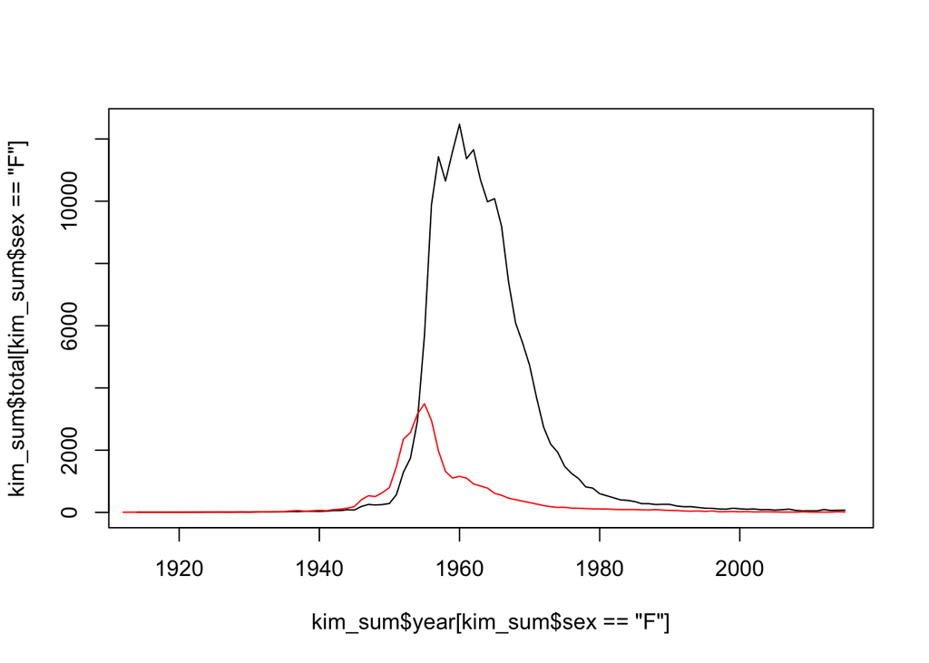

```r
kim_df <- filter(babynames, name == "Kim")
#kim_df <- babynames[babynames$name == "Kim",]
kim_grouped <- group_by(kim_df, year, sex)
kim_sum <- summarize(kim_grouped, total = sum(n))
plot(kim_sum$year[kim_sum$sex == "F"], kim_sum$total[kim_sum$sex == "F"], type = "l")
lines(kim_sum$year[kim_sum$sex == "M"], kim_sum$total[kim_sum$sex == "M"], col = "red")
```

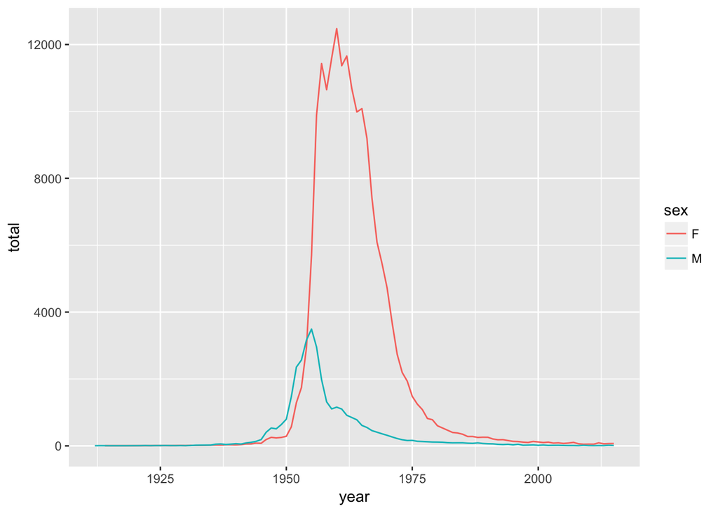

```r
qplot(year, total, color = sex, data = kim_sum, geom = "line") # ggplot-style alternative
```